# Biostatistics III in R

## (e)

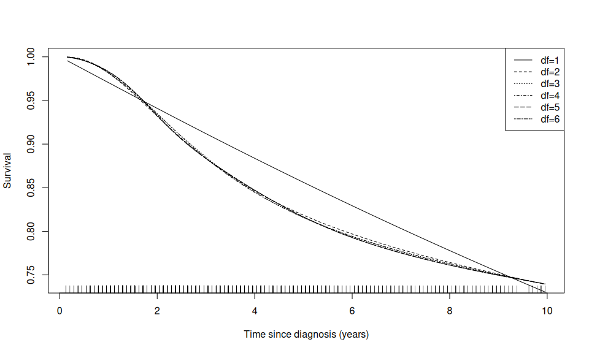

```r
## Baseline survival
fitaic0 <- stpm2(Surv(time, event) ~ year8594, data=melanoma0, df=6)
plot(fitaic0,newdata=data.frame(year8594=years[1]), lty=6, ci=FALSE,
     xlab="Time since diagnosis (years)")
for (i in 1:5 ) {
  fitaic <- stpm2(Surv(time, event) ~ year8594, data=melanoma0, df=i)
  lines(fitaic,newdata=data.frame(year8594=years[1]), lty=i)
}
legend("topright", legend=paste0("df=",1:6), lty=1:6)
```

The code for hazards is very similar:

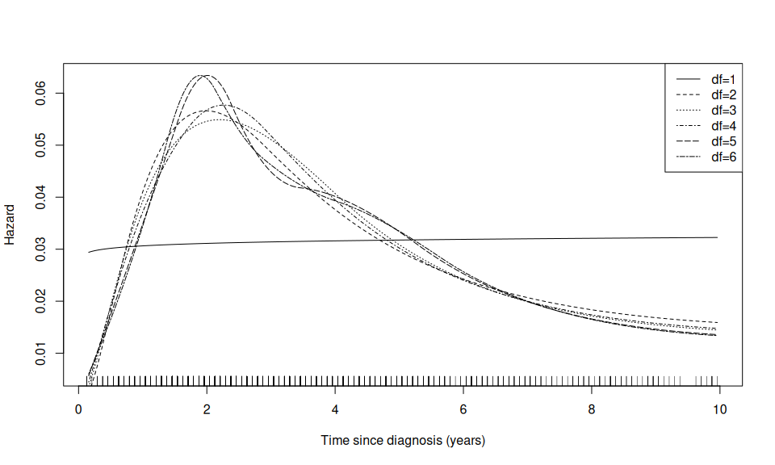

```r
## Baseline hazard
fitaic1 <- stpm2(Surv(time, event) ~ year8594, data=melanoma0, df=6)
plot(fitaic1,newdata=data.frame(year8594=years[1]), lty=6, type="haz",
     ci=FALSE, xlab="Time since diagnosis (years)", ylab="Hazard")
for (i in 1:5 ) {
  fitaic <- stpm2(Surv(time, event) ~ year8594, data=melanoma0, df=i)
  lines(fitaic,type="haz",newdata=data.frame(year8594=years[1]), lty=i)
}
legend("topright", legend=paste0("df=",1:6), lty=1:6)
```

With the exception of 1 df (the Weibull model), the survival and hazard functions show similar shapes, so as long we have enough knots our conclusions would be very similar.

## (f)

```r
fpmf <- stpm2(Surv(time, event) ~ sex + year8594 + agegrp,
              data=melanoma0, df=4)
summary(fpmf)
```

```
## Maximum likelihood estimation
##
## Call:
## stpm2(formula = Surv(time, event) ~ sex + year8594 + agegrp,
##     data = melanoma0, df = 4)
##
## Coefficients:
##                          Estimate Std. Error  z value     Pr(z)
## (Intercept)             -8.871693   0.588596 -15.0726 < 2.2e-16 ***
## sexFemale               -0.531564   0.065453  -8.1213 4.613e-16 ***
## year8594Diagnosed 85-94 -0.324071   0.066235  -4.8928 9.942e-07 ***
## agegrp45-59              0.283536   0.094174   3.0108  0.002606 **
## agegrp60-74              0.621701   0.090878   6.8411 7.860e-12 ***
## agegrp75+                1.223829   0.104452  11.7167 < 2.2e-16 ***
## nsx(log(time), df = 4)1  6.611562   0.577354  11.4515 < 2.2e-16 ***
## nsx(log(time), df = 4)2  5.715009   0.381092  14.9964 < 2.2e-16 ***
## nsx(log(time), df = 4)3 11.461392   1.145638  10.0044 < 2.2e-16 ***
## nsx(log(time), df = 4)4  5.019392   0.245502  20.4454 < 2.2e-16 ***
## ---
## Signif. codes:  0 '***' 0.001 '**' 0.01 '*' 0.05 '.' 0.1 ' ' 1
##
## -2 log L: 8241.324
```

```r
eform(fpmf)[2:6,]
```

```
## Profiling...
```

```
##                         exp(beta)     2.5 %    97.5 %
## sexFemale               0.5876853 0.5342863 0.6445097
## year8594Diagnosed 85-94 0.7231987 0.6577743 0.7927980
## agegrp45-59             1.3278161 1.1745477 1.4938284
## agegrp60-74             1.8620932 1.6645414 2.0746573
## agegrp75+               3.4001815 2.9272327 3.9212110
```

```r
## To test the overall effect of age with LR test
fpmf2 <- stpm2(Surv(time,event) ~ sex + year8594, data=melanoma0, df=4)
anova(fpmf, fpmf2)
```

```
## Likelihood Ratio Tests
## Model 1: fpmf, [negll]: (Intercept)+sexFemale+year8594Diagnosed 85-94+agegrp45-59+
##           agegrp60-74+agegrp75++nsx(log(time), df = 4)1+nsx(log(time), df = 4)2+
##           nsx(log(time), df = 4)3+nsx(log(time), df = 4)4
## Model 2: fpmf2, [negll]: (Intercept)+sexFemale+year8594Diagnosed 85-94+nsx(log(time), df
##           = 4)1+nsx(log(time), df = 4)2+nsx(log(time), df = 4)3+nsx(log(time), df = 4)4
##   Tot Df Deviance  Chisq Df Pr(>Chisq)
## 1     10   8241.3
## 2      7   8385.9 144.56  3  < 2.2e-16 ***
## ---
## Signif. codes:  0 '***' 0.001 '**' 0.01 '*' 0.05 '.' 0.1 ' ' 1
```

Undertaking a likelihood ratio test, there was strong evidence (p<1e-16) that age group contributed significantly to the model fit.

## (g)

```r
summary(fit <- coxph(Surv(time, event) ~ sex + year8594 + agegrp,
                     data=melanoma0))
```

```
## Call:
## coxph(formula = Surv(time, event) ~ sex + year8594 + agegrp,
##     data = melanoma0)
##
##   n= 5318, number of events= 960
##
##                             coef exp(coef) se(coef)      z Pr(>|z|)
## sexFemale               -0.53061   0.58825  0.06545 -8.107 5.19e-16 ***
## year8594Diagnosed 85-94 -0.33339   0.71649  0.06618 -5.037 4.72e-07 ***
## agegrp45-59              0.28283   1.32688  0.09417  3.003  0.00267 **
## agegrp60-74              0.62006   1.85904  0.09088  6.823 8.90e-12 ***
## agegrp75+                1.21801   3.38045  0.10443 11.663  < 2e-16 ***
## ---
## Signif. codes:  0 '***' 0.001 '**' 0.01 '*' 0.05 '.' 0.1 ' ' 1
##
##                         exp(coef) exp(-coef) lower .95 upper .95
## sexFemale                  0.5882     1.7000    0.5174    0.6688
## year8594Diagnosed 85-94    0.7165     1.3957    0.6293    0.8157
## agegrp45-59                1.3269     0.7536    1.1032    1.5959
## agegrp60-74                1.8590     0.5379    1.5557    2.2215
## agegrp75+                  3.3804     0.2958    2.7547    4.1483
##
## Concordance= 0.646  (se = 0.009 )
## Likelihood ratio test= 212.7  on 5 df,   p=<2e-16
## Wald test            = 217.9  on 5 df,   p=<2e-16
## Score (logrank) test = 226.8  on 5 df,   p=<2e-16
```

```r
anova(fit)
```

```
## Analysis of Deviance Table
##  Cox model: response is Surv(time, event)
## Terms added sequentially (first to last)
##
##           loglik   Chisq Df Pr(>|Chi|)
## NULL     -7899.0
## sex      -7873.4  51.235  1  8.193e-13 ***
## year8594 -7864.4  18.089  1  2.109e-05 ***
## agegrp   -7792.7 143.365  3  < 2.2e-16 ***
## ---
## Signif. codes:  0 '***' 0.001 '**' 0.01 '*' 0.05 '.' 0.1 ' ' 1
```

## (h)

```r
## (h) Change to time-varying effect of agegrp2:4
## NB: including main effect of agegrp
fpmh <- stpm2(Surv(time,event) ~ sex + year8594 + agegrp2 + agegrp3 + agegrp4,
              data=melanoma0, tvc=list(agegrp2 = 2, agegrp3 = 2, agegrp4 = 2),
              df=4)
summary(fpmh)
```

```
## Maximum likelihood estimation
##
## Call:
## stpm2(formula = Surv(time, event) ~ sex + year8594 + agegrp2 +
##     agegrp3 + agegrp4, data = melanoma0, tvc = list(agegrp2 = 2,
##     agegrp3 = 2, agegrp4 = 2), df = 4)
##
## Coefficients:
##                                               Estimate Std. Error z value     Pr(z)
## (Intercept)                                 -11.430385   1.352688 -8.4501 < 2.2e-16 ***
## sexFemale                                    -0.525715   0.065423 -8.0356 9.312e-16 ***
## year8594Diagnosed 85-94                      -0.328279   0.066318 -4.9501 7.418e-07 ***
## agegrp2                                       1.895592   1.452011  1.3055 0.1917245
## agegrp3                                       1.672483   1.400490  1.1942 0.2323947
## agegrp4                                       5.203061   1.357570  3.8326 0.0001268 ***
## nsx(log(time), df = 4)1                       8.987875   1.342336  6.6957 2.146e-11 ***
## nsx(log(time), df = 4)2                       7.580891   0.984030  7.7039 1.320e-14 ***
## nsx(log(time), df = 4)3                      15.766479   2.409215  6.5442 5.980e-11 ***
## nsx(log(time), df = 4)4                       6.513171   0.703624  9.2566 < 2.2e-16 ***
## as.numeric(agegrp2):nsx(log(time), df = 2)1  -2.659503   2.584875 -1.0289 0.3035404
## as.numeric(agegrp2):nsx(log(time), df = 2)2  -0.805394   0.592422 -1.3595 0.1739901
## nsx(log(time), df = 2)1:as.numeric(agegrp3)  -1.510981   2.494029 -0.6058 0.5446214
## nsx(log(time), df = 2)2:as.numeric(agegrp3)  -0.718230   0.570820 -1.2582 0.2083038
## nsx(log(time), df = 2)1:as.numeric(agegrp4)  -6.730551   2.427744 -2.7723 0.0055653 **
## nsx(log(time), df = 2)2:as.numeric(agegrp4)  -2.029783   0.549990 -3.6906 0.0002237 ***
## ---
## Signif. codes:  0 '***' 0.001 '**' 0.01 '*' 0.05 '.' 0.1 ' ' 1
##
## -2 log L: 8212.053
```

```r
## LR test comparing fpmh (non-PH for agegrp2:4) with fpmf(PH for agegrp2:4)
anova(fpmh, fpmf)
```

```
## Likelihood Ratio Tests
## Model 1: fpmh, [negll]: (Intercept)+sexFemale+year8594Diagnosed 85-94+agegrp2+agegrp3+
##           agegrp4+nsx(log(time), df = 4)1+nsx(log(time), df = 4)2+nsx(log(time), df =
##           4)3+nsx(log(time), df = 4)4+as.numeric(agegrp2):nsx(log(time), df = 2)1+
##           as.numeric(agegrp2):nsx(log(time), df = 2)2+nsx(log(time), df =
##           2)1:as.numeric(agegrp3)+nsx(log(time), df = 2)2:as.numeric(agegrp3)+
##           nsx(log(time), df = 2)1:as.numeric(agegrp4)+nsx(log(time), df =
##           2)2:as.numeric(agegrp4)
## Model 2: fpmf, [negll]: (Intercept)+sexFemale+year8594Diagnosed 85-94+agegrp45-59+
##           agegrp60-74+agegrp75++nsx(log(time), df = 4)1+nsx(log(time), df = 4)2+
##           nsx(log(time), df = 4)3+nsx(log(time), df = 4)4
##   Tot Df Deviance  Chisq Df Pr(>Chisq)
## 1     16   8212.1
## 2     10   8241.3 29.271  6  5.406e-05 ***
## ---
## Signif. codes:  0 '***' 0.001 '**' 0.01 '*' 0.05 '.' 0.1 ' ' 1
```

There is strong evidence of a non-proportional effect of age.

We could also investigate the non-proportional effect of age with penalized models, where sp is the optimal smoothing parameters estimated from models without sp argument:

```r
## I investigated the non-proportional effect of age with penalized models
## here, sp is the optimal smoothing parameters estimated from models without sp argument
pfit0 <- pstpm2(Surv(time,event) ~ sex + year8594 + agegrp,
                data=melanoma0, sp=0.1359685)

## The time-dependent effects including linear forms of age groups
pfit1 <- pstpm2(Surv(time,event) ~ sex + year8594 + agegrp2 + agegrp3 + agegrp4,
                tvc=list(agegrp2=7,agegrp3=7,agegrp4=7),
                data=melanoma0, sp=c( 0.1429949, 1.6133966, 1.3183117, 1.9958815))
anova(pfit1, pfit0)## the results also suggest there is strong evidence
```

```
## Likelihood Ratio Tests
## Model 1: pfit1, [negll]: (Intercept)+sexFemale+year8594Diagnosed 85-94+s(log(time)).1+
##           s(log(time)).2+s(log(time)).3+s(log(time)).4+s(log(time)).5+s(log(time)).6+
##           s(log(time)).7+s(log(time)).8+s(log(time)).9+s(log(time)):agegrp2.1+
##           s(log(time)):agegrp2.2+s(log(time)):agegrp2.3+s(log(time)):agegrp2.4+
##           s(log(time)):agegrp2.5+s(log(time)):agegrp2.6+s(log(time)):agegrp2.7+
##           s(log(time)):agegrp3.1+s(log(time)):agegrp3.2+s(log(time)):agegrp3.3+
##           s(log(time)):agegrp3.4+s(log(time)):agegrp3.5+s(log(time)):agegrp3.6+
##           s(log(time)):agegrp3.7+s(log(time)):agegrp4.1+s(log(time)):agegrp4.2+
##           s(log(time)):agegrp4.3+s(log(time)):agegrp4.4+s(log(time)):agegrp4.5+
##           s(log(time)):agegrp4.6+s(log(time)):agegrp4.7
## Model 2: pfit0, [negll]: (Intercept)+sexFemale+year8594Diagnosed 85-94+agegrp45-59+
##           agegrp60-74+agegrp75++s(log(time)).1+s(log(time)).2+s(log(time)).3+
##           s(log(time)).4+s(log(time)).5+s(log(time)).6+s(log(time)).7+s(log(time)).8+
##           s(log(time)).9
##   Tot Df Deviance  Chisq     Df Pr(>Chisq)
## 1 21.555   8205.8
## 2 14.124   8230.9 25.098 7.4306   0.001003 **
## ---
## Signif. codes:  0 '***' 0.001 '**' 0.01 '*' 0.05 '.' 0.1 ' ' 1
```

## (i)

The baseline hazard is shown below. This baseline is for the youngest age group who are male and diagnosed in 1975–1984, i.e, when all the covariates are equal to zero.

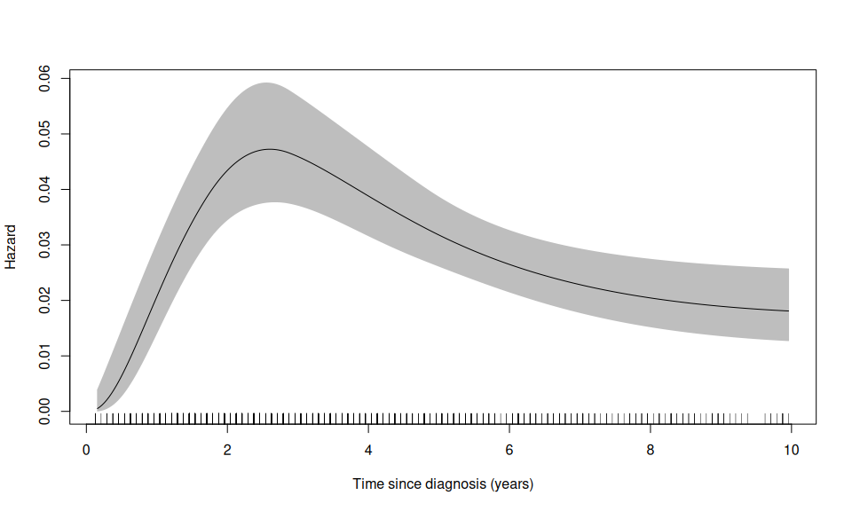

```r
## Plot of baseline hazard with fpmh
newdata1 <- data.frame(sex="Male",year8594="Diagnosed 75-84",
                       agegrp2=0, agegrp3=0, agegrp4=0)
plot(fpmh, newdata=newdata1, xlab="Time since diagnosis (years)",
     type="haz")
```

## (j)

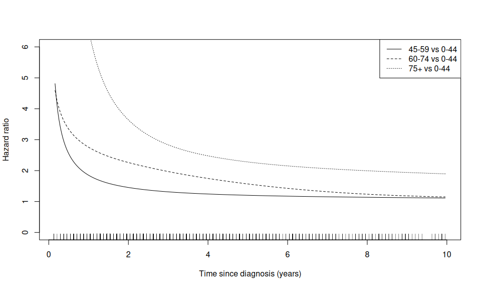

```r
plot(fpmh, newdata=newdata1, xlab="Time since diagnosis (years)",
     type="hr",var="agegrp2", ci=FALSE, ylim=c(0,6))
lines(fpmh, newdata=newdata1, type="hr", var="agegrp3", lty=2)
lines(fpmh, newdata=newdata1, type="hr", var="agegrp4", lty=3)
legend("topright", legend=paste0(agegrps[-1]," vs 0-44"), lty=1:3)
```

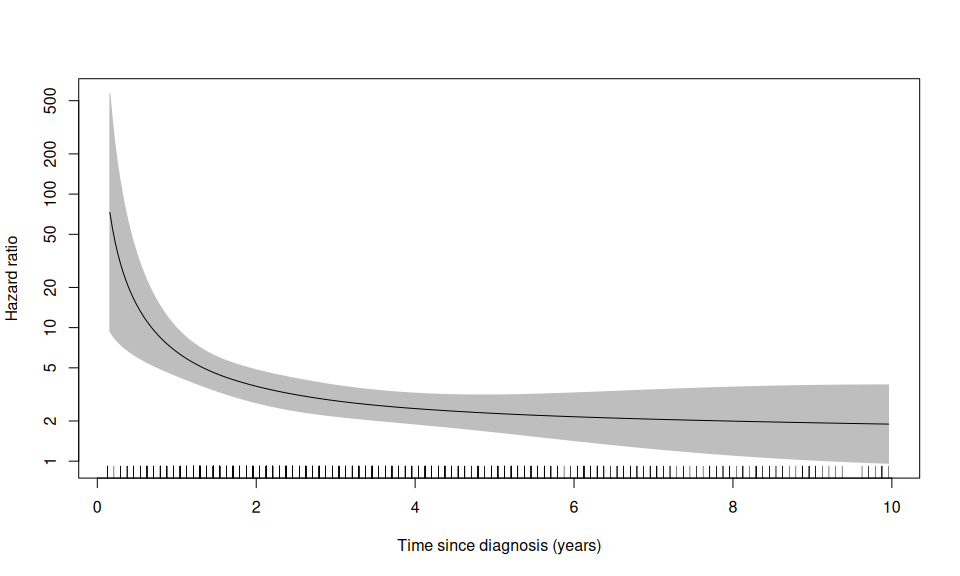

```
    The hazard ratios decrease as a function of follow-up time. The
    hazard ratio is so high during the early years of follow-up
    because the hazard in the reference group is close to
    zero. The hazard ratio for the oldest age
    group with 95% confidence intervals is also shown.
```

```r
plot(fpmh, newdata=newdata1,
     type="hr", log="y",
     exposed=function(data) transform(data,agegrp4=agegrp4+1), # same as var="agegrp4"
     xlab="Time since diagnosis (years)")
```

## (k)

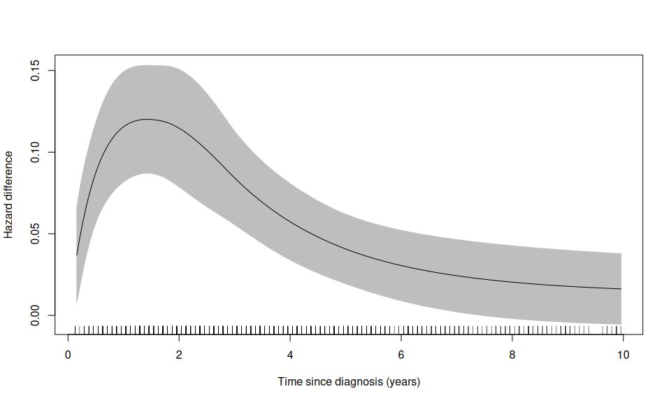

```r
plot(fpmh,newdata=newdata1,
     type="hdiff", var="agegrp4",
     xlab="Time since diagnosis (years)")
```

The hazard difference is small early on, despite the hazard ratio being large, because the underlying hazard is so low.

## (l)

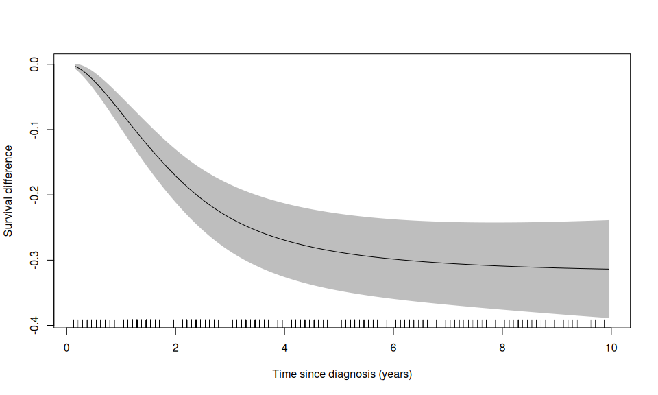

```r
plot(fpmh,newdata=newdata1,
     type="sdiff", var="agegrp4",
     xlab="Time since diagnosis (years)")
```

## (m)

```r
lapply(1:3, function(i) {
    fitdf <- stpm2(Surv(time,event) ~ sex + year8594 + agegrp2 + agegrp3 + agegrp4,
                   data=melanoma0, tvc=list(agegrp2 = i, agegrp3 = i, agegrp4 = i),
                   df=4)
    data.frame(i,
               aic=AIC(fitdf),
               bic=BIC(fitdf))
}) |> do.call(what=rbind)
```

```
##   i      aic      bic
## 1 1 8245.961 8331.486
## 2 2 8244.053 8349.315
## 3 3 8248.623 8373.621
```

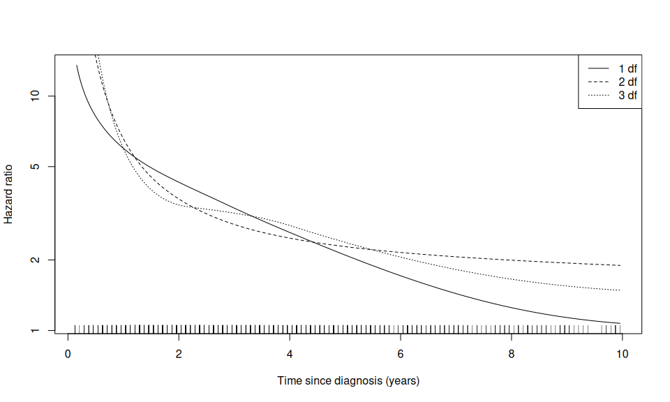

```r
## Plots with different df
fitdf1 <- stpm2(Surv(time,event) ~ sex + year8594 + agegrp2 + agegrp3 + agegrp4,
                data=melanoma0,
                tvc = list(agegrp2 = 1, agegrp3 = 1, agegrp4 = 1), df=4)

plot(fitdf1, newdata = newdata1,
     type="hr", ci=FALSE, log="y", var="agegrp4",
     xlab="Time since diagnosis (years)")
for (i in 2:3 ) {
    fitdf <- stpm2(Surv(time,event) ~ sex + year8594 + agegrp2 + agegrp3 + agegrp4,
                   data=melanoma0, tvc=list(agegrp2 = i, agegrp3 = i, agegrp4 = i),
                   df=4)
    lines(fitdf, newdata=newdata1,
          type="hr", lty=i,
          var="agegrp4")
}
legend("topright", legend=c("1 df", "2 df", "3 df"), lty=1:3)
```